# Feature Engineering (Focus on Text)

# Learning objectives

By the end of this lab session, the students should be able to

1. Appreciate the importance of defining good features.
2. Define features for text.
3. Perform feature engineering on a real (text) data.

# Feature Engineering

Feature engineering is the art of defining good features. Here we define a feature as a measurable characteristic of objects that are under consideration. For example, height (measured in meters) and age (measured in years) are features of people. In machine learning, feature engineering is part of data preprocessing. In machine learning we never work with real objects, we only deal with features defined for those objects, hence the success of a machine learning project often depends on the quality of the features. A good set of features do not only tell us what an object is but also what it is not (see Figure 2).

[figure not shown]

Figure 1. Cat and some cat features

Outside computer science or machine learning, feature is synonymous with variable.

[figure not shown]

Figure 2. Features on cats and dogs

The usefulness of feature engineering becomes more apparent when the raw data is not in numerical format and when we need to define higher level features. Some machine learning algorithms incorporate feature transformation to obtain higher level features and often they result in good performance. However, there is always a room for creativity and as Domingos put it “there is no replacement for the smarts you put into feature engineering”

# Features that can be used for some data

| Data | Feature |
| --- | --- |
| images | pixels, contours, textures |
| signal | samples, spectograms |
| time series | ticks, trends, reversals |
| biological | dna, marker sequences, genes |
| text | words, grammatical classes and relations |

## Advice on feature engineering

1. Use domain knowledge to construct a better set of “ad hoc” features.
2. Try different and as many features (as your resources will allow) and apply feature reduction techniques.
3. Apply normalization.
4. Subsample data.

## Points to remember

1. Redundant features help each other except in the case when they are perfectly correlated.
2. Two features that are useless by themselves can be useful together (e.g. XOR problem ).

# Tutorial on extracting features from text

This part of the tutorial will illustrate how to generate numerical features from text. The tutorial here is for the large part based from the paper of Kobayashi et al. (2017).

Our text are job advertisements posted online and our goal is to extract features that may be useful for job classification and/or automatic job information extraction from job descriptions.

## Getting to know the data

The data file contain 150 English vacancies. Each file is a vacancy. You can download the data in Blackboard.

## Import data

We are going to use the `tm` library for our text processing. Since we have separate files for each vacancy it is convenient to store them in a folder in your computer and use the `DirSource` function to read the files in R. If the text are in a table , use the `VectorSource` or ``DataframeSource` function. You can also specify a URI or XML source. To see the list of possible input locations invoke the following command

```r
library(tm)
getSources()
```

```
## [1] "DataframeSource" "DirSource"       "URISource"       "VectorSource"
## [5] "XMLSource"       "ZipSource"
```

Once we have specified the input location (in our case the directory source), we create a corpus of documents. In the language of text mining, a corpus is a collection of documents. This is done using the `VCorpus` function. By the way, in specifying the input location make sure to provide the correct path.

```r
job_adverts <- VCorpus(DirSource("vladi"))
```

Let us see whether the documents were properly imported. To inspect the content of the first document invoke

```r
job_adverts[[1]]$content
```

```
## [1] "  .Net development   Architects and designs software solutions based on requirements  collaborates with product owners  team leads and other architects SMEs  studying systems flow  data usage  and work processes  investigating problem areas  following the software development lifecycle.   Do…
```

## Document Cleaning

For this tutorial we are going to use words as features, hence our goal is to extract the words also called word tokenization. However, prior to that we want to clean the data by apply standard text preprocessing procedures such as lowercase transformation and extra whitespace removal. We can easily do this using the `tm_map` function.

```r
job_adverts <- tm_map(job_adverts, content_transformer(tolower))
job_adverts <- tm_map(job_adverts, stripWhitespace)
```

See the effect of the preprocessing for the first document.

```r
job_adverts[[1]]$content
```

```
## [1] " .net development architects and designs software solutions based on requirements collaborates with product owners team leads and other architects smes studying systems flow data usage and work processes investigating problem areas following the software development lifecycle. documents and …
```

Aside from the preprocessing procedures we applied above other common preprocessing procedures include punctuation removal and number removal.

What are the advantage and disadvantage of applying punctuation and number removal?

## Feature Engineering

One way to construct features is to build the so-called document-term matrix wherein the rows are the documents, the columns are the words (or tokens), and the entries are the raw frequencies of the words in each document. The dimensions of the matrix is equal to the number of documents by the number of unique tokens. This matrix is necessarily sparse since most words only appear in few documents.

Let us construct this using the `DocumentTermMatrix` function. Note that we decided to remove the punctuation and the numbers.

```r
dtm <- DocumentTermMatrix(job_adverts,
                          control = list(
                            removePunctuation=TRUE,
                            removeNumbers=TRUE
                            )
                          )
```

What is the dimensionality of the resulting document-by-term matrix?

Of course we can also define features aside from words. We can define bi-grams (consecutive words) and grammar based features. In this tutorial we focus on word features. Note that the document-by-term matrix is stored as a sparse matrix.

From the document-by-term matrix we can investigate some statistics such as the highest and lowest frequencies.

```r
library(slam)
summary(col_sums(dtm))
```

```
##     Min.  1st Qu.   Median     Mean  3rd Qu.     Max.
##    1.000    1.000    2.000    6.365    4.000 2119.000
```

Let us identify the top ten most frequent words

```r
sort(col_sums(dtm), decreasing=TRUE)[1:10]
```

```
##        and        the       with experience        for     skills
##       2119        797        514        440        381        253
##   customer    ability management   business
##        192        187        182        170
```

We can also use the `findFreqTerms` to find the most frequent terms. Below is the code to find the terms with a frequency of at least 100.

```r
findFreqTerms(dtm, lowfreq=100)
```

```
##  [1] "ability"    "all"        "and"        "business"   "customer"
##  [6] "customers"  "experience" "for"        "management" "project"
## [11] "sales"      "skills"     "team"       "that"       "the"
## [16] "with"       "work"       "years"
```

Aside from finding the frequent terms we can also identify which terms correlate with a given term.

```r
findAssocs(dtm, terms = "verbal", corlimit = 0.3)
```

```
## $verbal
##      written       highly        drive      driving presentation
##         0.58         0.46         0.35         0.32         0.32
##    excellent        solid
##         0.30         0.30
```

Notice that some of the most frequent words are prepositions. In terms of semantic contribution, they do not contribute to the meaning that much so better remove them, these words are also called stopwords.

```r
dtm_new <- dtm[,!(Terms(dtm) %in% findFreqTerms(dtm, lowfreq = 100))]

# make sure that we also remove empty docs
dtm_new<-dtm_new[row_sums(dtm_new)>0,]
```

The new top frequent terms are

```r
findFreqTerms(dtm_new, lowfreq = 60)
```

```
##  [1] "analysis"      "are"           "communication" "data"
##  [5] "degree"        "design"        "develop"       "development"
##  [9] "ensure"        "including"     "knowledge"     "maintain"
## [13] "manage"        "must"          "new"           "other"
## [17] "our"           "plans"         "process"       "products"
## [21] "projects"      "provide"       "required"      "services"
## [25] "store"         "strong"        "support"       "systems"
## [29] "technical"     "use"           "working"       "your"
```

The tf-idf can be used for term filtering to remove unimportant terms.

Let us use tf-idf to further remove terms that are less important. Here we set the threshold slightly higher than the median. Can you guess the reason for selecting this threshold?

```r
term_tfidf<-tapply(dtm_new$v/row_sums(dtm_new)[dtm_new$i], dtm_new$j, mean) * log2(nDocs(dtm_new)/col_sums(dtm_new>0))
summary(term_tfidf)
```

```
##     Min.  1st Qu.   Median     Mean  3rd Qu.     Max.
## 0.009263 0.029505 0.041785 0.052479 0.059253 0.850449
```

```r
dtm_new<-dtm_new[,term_tfidf>=0.042]
dtm_new<-dtm_new[row_sums(dtm_new)>0,]
summary(col_sums(dtm_new))
```

```
##    Min. 1st Qu.  Median    Mean 3rd Qu.    Max.
##   1.000   1.000   1.000   2.604   2.000  87.000
```

```r
dim(dtm_new)
```

```
## [1]  150 2001
```

What are the dimensions of the resulting document-by-term matrix after filtering with tf-idf?

What are the most frequent terms?

Let us create a wordcloud to get an idea of the content of our vacancy data.

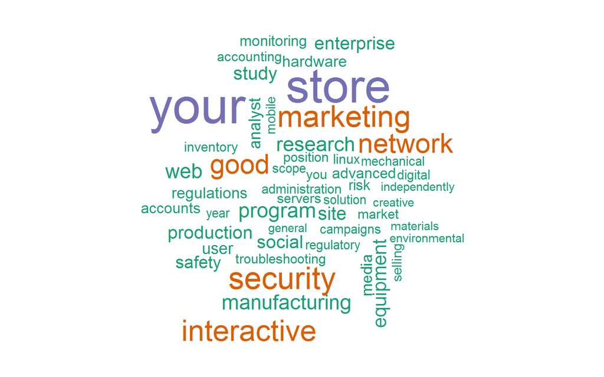

```r
library(wordcloud)
freq = data.frame(freqterms=sort(colSums(as.matrix(dtm_new)), decreasing=TRUE))

wordcloud(rownames(freq), freq[,1], max.words=50, colors=brewer.pal(3, "Dark2"))
```

What vacancies do you think dominate our data?

Our document-by-term matrix can be converted to a dense matrix using the `as.matrix` function and can be used as input to supervised and unsupervised machine learning techniques.

# Summary

The feature engineering presented here is based on constructing the document by term matrix and is based on bag-of-words model which assumes that a document is a collection words (ignoring word order information), of course there are other approaches such as using one-hot encoding (more about this during the session on neural network). Furthermore, we can also apply other preprocessing and filtering techniques depending on the objectives (and often on the judgment of the researcher) of the project.

As further reading on feature engineering techniques for other raw data types. I encourage you to do a simple search on google scholar with the following keywords : “feature extraction data_type>” where “data_type” is either image, signal or time series.

Vladimer Kobayashi

3 november 2017